# STA 145

Yuchen Liu,

2023-06-14

Q1) Example: Midge Wing Length

In this example, we have data on the wing length of nine members of a species of midge, which are small, two-winged flies. The observations, in increasing order, are as follows: (1.64, 1.70, 1.72, 1.74, 1.82, 1.82, 1.82, 1.90, 2.08). We want to make inferences about the population mean (θ) and variance (σ^2) based on these measurements.

Let’s consider two different cases for data analysis:

Case 1: Prior information suggests that E(σ^2_0) = 0.01. In this case, we can specify the joint prior distribution as follows:

p(θ, σ^2) = p(θ) p(σ^2) = N(θ, μ_0, τ^2_0) × p(σ^2); σ^2 ~ gamma(ν_0/2, (ν_0/2)σ^2_0),

where β represents additional parameters for the prior distributions. This formulation allows for more flexibility by incorporating prior information on both σ^2 and σ^2_0.

These are the different options for data analysis that can be considered in this study.

## Case 1

Obtain the form of the full conditional distributions and write the Gibbs Sampler algorithm

- $p\left(\theta \mid \sigma^{2}, y_{1}, \ldots, y_{n}\right)$ given by $\left\{\theta \mid \sigma^{2}, y_{1}, \ldots, y_{n}\right\} \sim \operatorname{normal}\left(\mu_{n}, \tau_{n}^{2}\right)$ with
  $$\mu_{n}=\frac{\mu_{0} / \tau_{0}^{2}+n \bar{y} /
  \sigma^{2}}{1 / \tau_{0}^{2}+n / \sigma^{2}} \text { and }
  \tau_{n}^{2}=\left(\frac{1}{\tau_{0}^{2}}+\frac{n}{\sigma^{2}}\right)^{-1}
  .$$
- $\left\{\sigma^{2} \mid \theta, y_{1}, \ldots, y_{n}\right\} \sim$ inverse-gamma $\left(\nu_{n} / 2, \nu_{n} \sigma_{n}^{2}(\theta) / 2\right)$, where
  $$\nu_{n}=\nu_{0}+n, \quad
  \sigma_{n}^{2}(\theta)=\frac{1}{\nu_{n}}\left[\nu_{0} \sigma_{0}^{2}+n
  s_{n}^{2}(\theta)\right]$$
  and $s_{n}^{2}(\theta)=\sum\left(y_{i}-\theta\right)^{2} / n$

#### 1. Run a Gibbs sampler of at least 5,000 iterations and attach the R script.

```r
##data
mu0<-1.9  ; k0<-1
s20<-.01 ; nu0<-1
t20<-0.95^2
## data
y<-c(1.64,1.70,1.72,1.74,1.82,1.82,1.82,1.90,2.08)
n<-length(y) ; mean.y <- ybar<-mean(y) ; var.y <- s2<-var(y)

## posterior inference
kn<-k0+n ; nun<-nu0+n
mun<- (k0*mu0 + n*ybar)/kn
s2n<- (nu0*s20 +(n-1)*s2 +k0*n*(ybar-mu0)^2/(kn))/(nun)
mun
```

```
## [1] 1.814
```

```r
s2n
```

```
## [1] 0.015324
```

```r
MLE_1 <- ybar

## MLE 2

MLE_2 <- s2


## MLE 2

MLE_3 <- 1/s2

dinvgamma<-function(x,a,b) {
ld<- a*log(b) -lgamma(a) -(a+1)*log(x)  -b/x
exp(ld)
                            }

gs<-100
theta<-seq(1.6,2.0,length=gs)
is2<-seq(15,160 ,length=gs)
s2g<-seq(.001,.045,length=gs)

ld.th.is2<-ld.th.s2<-matrix(0,gs,gs)
for(i in 1:gs) { for(j in 1:gs) {
    ld.th.is2[i,j]<- dnorm(theta[i],mun,1/sqrt( is2[j] *10) ,log=TRUE) +
                   dgamma(is2[j],10/2,10*s2n/2, log=TRUE )
    ld.th.s2[i,j]<- dnorm(theta[i],mun,sqrt(s2g[j]/10) ,log=TRUE) +
                    log( dinvgamma(s2g[j],10/2,10*s2n/2 ))
                     }}
```

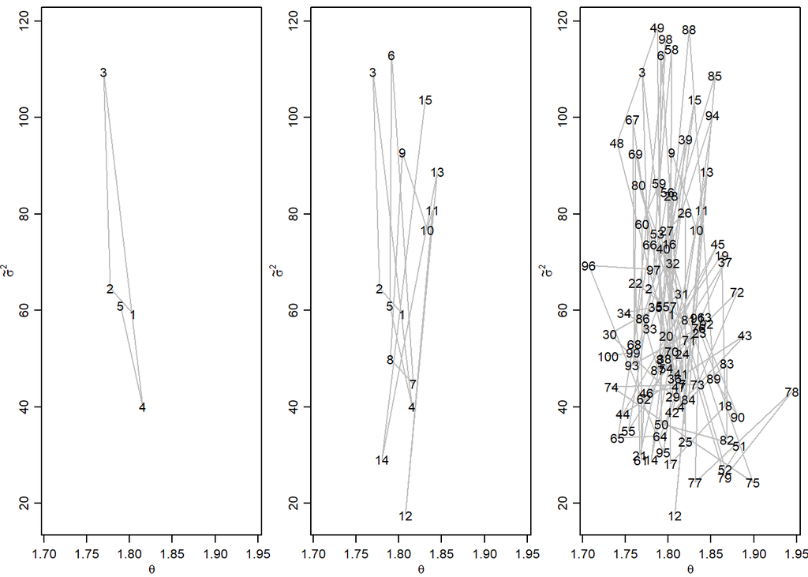

```r
set.seed(1)
S<-5000 # Number of samples
PHI<-matrix(nrow=S,ncol=2)
PHI[1,]<-phi<-c( mean.y, 1/var.y)

## Gibbs sampling algorithm
for(s in 2:S) {

# generate a new theta value from its full conditional
mun<-  ( mu0/t20 + n*mean.y*phi[2] ) / ( 1/t20 + n*phi[2] )
t2n<- 1/( 1/t20 + n*phi[2] )
phi[1]<-rnorm(1, mun, sqrt(t2n) )

# generate a new sigma^2 value from its full conditional
nun<- nu0+n
s2n<- (nu0*s20 + (n-1)*var.y + n*(mean.y-phi[1])^2 ) /nun
phi[2]<- rgamma(1, nun/2, nun*s2n/2)

PHI[s,]<-phi

                }

par(mfrow=c(1,3),mar=c(2.75,2.75,.5,.5),mgp=c(1.70,.70,0))
m1<-5
plot( PHI[1:m1,],type="l",xlim=range(PHI[1:100,1]), ylim=range(PHI[1:100,2]),
       lty=1,col="gray",xlab=expression(theta),ylab=expression(tilde(sigma)^2))
text(  PHI[1:m1,1], PHI[1:m1,2], c(1:m1) )

m1<-15
plot( PHI[1:m1,],type="l",xlim=range(PHI[1:100,1]), ylim=range(PHI[1:100,2]),
       lty=1,col="gray",xlab=expression(theta),ylab=expression(tilde(sigma)^2))
text(  PHI[1:m1,1], PHI[1:m1,2], c(1:m1) )

m1<-100
plot( PHI[1:m1,],type="l",xlim=range(PHI[1:100,1]), ylim=range(PHI[1:100,2]),
       lty=1,col="gray",xlab=expression(theta),ylab=expression(tilde(sigma)^2))
text(  PHI[1:m1,1], PHI[1:m1,2], c(1:m1) )
```

```r
PHI2<-PHI
```

#### 2. Using posterior quantities (e.g., plots, quantiles, means, medians, posterior probabilities) describe the marginal and joint posterior distributions (including in Case 2 the marginal posterior distribution of σ2 0 and β). (10 points)

[figure not shown]

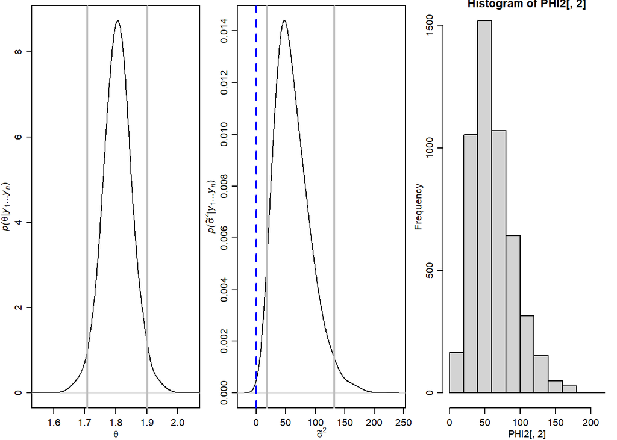

```r
## posterior marginal density
par(mfrow=c(1,3),mar=c(2.75,2.75,.5,.5),mgp=c(1.70,.70,0))
sseq<-1:1000




plot(density(PHI2[,1],adj=2),  xlab=expression(theta),main="",
     xlim=c(1.55,2.05),
 ylab=expression( paste(italic("p("),
     theta,"|",italic(y[1]),"...",italic(y[n]),")",sep="")))
abline(v=quantile(PHI2[,1],prob=c(.025,.975)),lwd=2,col="gray")

plot(density(PHI2[,2],adj=2), xlab=expression(tilde(sigma)^2),main="",
     ylab=expression( paste(italic("p("),
     tilde(sigma)^2,"|",italic(y[1]),"...",italic(y[n]),")",sep="")))
abline(v=quantile(PHI2[,2],prob=c(.025,.975)),lwd=2,col="gray")

abline(v=0.01,lwd=2,col="blue",lty=2)

hist(PHI2[,2])
```

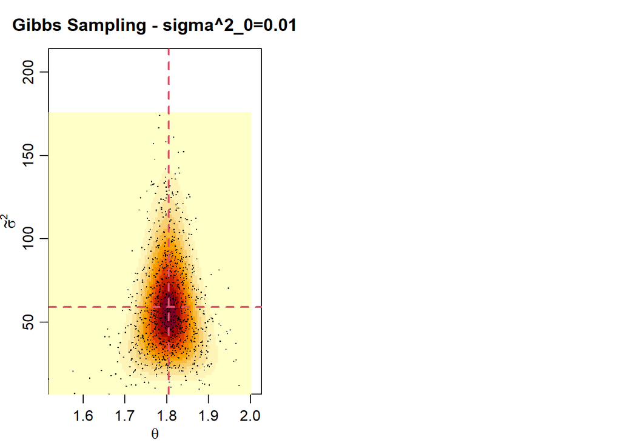

```r
## joint marginal
par(mfrow=c(1,2),mar=c(2.75,2.75,2.75,2.75),mgp=c(1.70,.70,0))
sseq<-1:1000

image( mean.grid,prec.grid,post.grid,
     xlab=expression(theta), ylab=expression(tilde(sigma)^2) ,
     xlim=range(PHI2[,1]),ylim=range(PHI2[,2]), main="Gibbs Sampling - sigma^2_0=0.01")
points(PHI2[sseq,1],PHI2[sseq,2],pch=".",cex=1.25 )
abline(v=MLE_1,lwd=2,lty=2,col=2)
abline(h=MLE_3,lwd=2,lty=2,col=2)
```

```r
quantile(PHI2[,1],prob=c(.025,.975))
```

```
##     2.5%    97.5%
## 1.709142 1.901795
```

```r
quantile(PHI2[,2],prob=c(.025,.975))
```

```
##     2.5%    97.5%
##  18.2643 132.4506
```

```r
summary(PHI2)
```

```
##        V1              V2
##  Min.   :1.518   Min.   :  6.978
##  1st Qu.:1.776   1st Qu.: 40.548
##  Median :1.805   Median : 56.510
##  Mean   :1.805   Mean   : 61.958
##  3rd Qu.:1.835   3rd Qu.: 78.984
##  Max.   :2.026   Max.   :214.026
```

```r
apply(PHI2,2,sd)
```

```
## [1]  0.04801766 29.74623749
```

#### 4. Implement the MCMC diagnostics. (10 points)

```r
set.seed(1)
S<-5000

s2.postsample<-1/rgamma(S,  (nu0+n)/2, s2n*(nu0+n)/2 )

theta.postsample<-rnorm(S, mun, sqrt(s2.postsample/(k0+n)))


quantile(theta.postsample, c(.025,.975))
```

```
##     2.5%    97.5%
## 1.714375 1.889651
```

```r
##
layout(matrix(c(1,1,2,3),2,2,byrow=T))
par(mar=c(3,3,1,1),mgp=c(1.75,.75,0))
image(theta,s2g,exp(ld.th.s2),xlab=expression(theta),
       ylab=expression(sigma^2),xlim=c(1.60,2.0),ylim=c(.001,.07) )
points(theta.postsample[1:5000], s2.postsample[1:5000],pch=".",
   xlab=expression(theta),ylab=expression(sigma^2),xlim=c(1.65,1.95),
   ylim=c(.005,.07) )
plot(density(s2.postsample,adjust=3),main="",xlab=expression(sigma^2),
     xlim=c(0,.075),ylab=expression( paste(italic("p("),
     sigma^2,"|",italic(y[1]),"...",italic(y[n]),")",sep="")))
plot(density(theta.postsample,adjust=3),main="",xlab=expression(theta),
     xlim=c(1.60,2.0),ylab=expression( paste(italic("p("),
     theta,"|",italic(y[1]),"...",italic(y[n]),")",sep="")))
quantile( theta.postsample,c(.025,.975))
```

```
##     2.5%    97.5%
## 1.714375 1.889651
```

```r
abline(v=quantile( theta.postsample,c(.025,.975)),col="gray",lwd=2)

## t-test based confidence interval
n<-length(y) ; ybar<-mean(y) ; s2<-var(y)

ybar+qt( c(.025,.975), n-1) *sqrt(s2/n)
```

```
## [1] 1.704583 1.904306
```

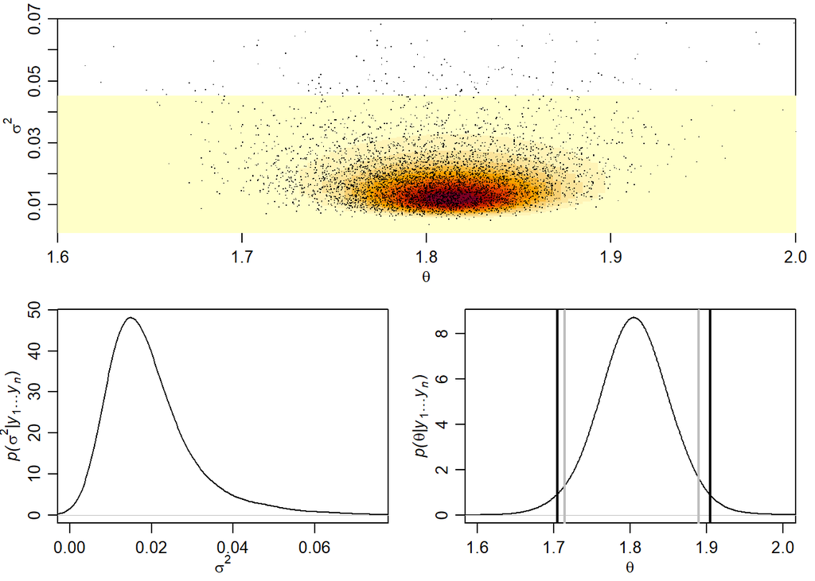

```r
abline( v= ybar+qt( c(.025,.975), n-1) *sqrt(s2/n), col="black",lwd=2)
```

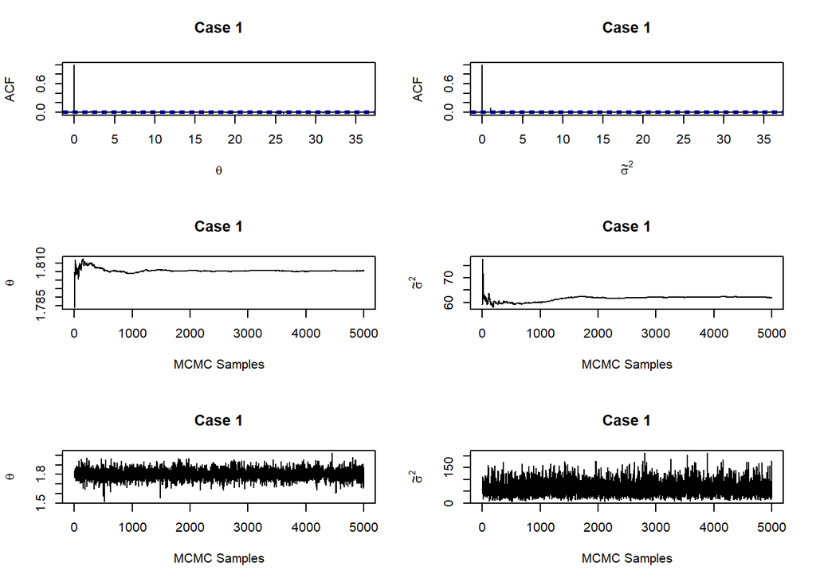

```r
library(dlm)
library(dlm)
par(mfrow=c(3,2))

# Autocorrelation function

acf(PHI2[,1],main="Case 1", xlab=expression(theta))
acf(PHI2[,2],main="Case 1", xlab=expression(tilde(sigma)^2))

# Ergodic mean

plot(ergMean(PHI2[,1]),main="Case 1", ylab=expression(theta),xlab="MCMC Samples",type="l")
plot(ergMean(PHI2[,2]),main="Case 1", ylab=expression(tilde(sigma)^2),xlab="MCMC Samples",type="l")

# Mixing

plot(PHI2[,1],main="Case 1", ylab=expression(theta),xlab="MCMC Samples",type="l")
plot(PHI2[,2],main="Case 1", ylab=expression(tilde(sigma)^2),xlab="MCMC Samples",type="l")
```

see appendix for more

## Case2

basic case a1 = 1 #### 1. Run a Gibbs sampler of at least 5,000 iterations and attach the R script.

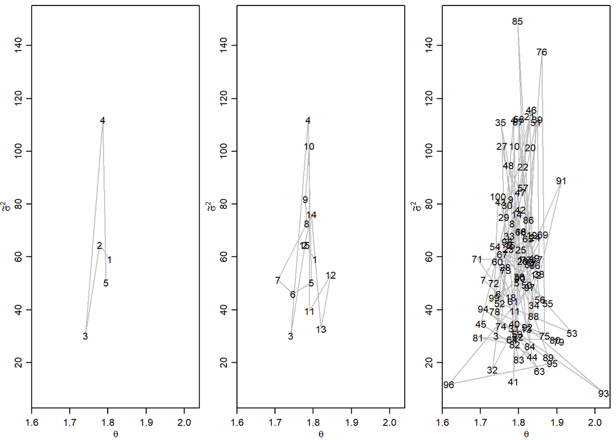

```r
a = 1
a1 = 1
b = 100
set.seed(1)
S<-5000 # Number of samples
a<-1
b<-100

PHI<-matrix(nrow=S,ncol=3) # New change ncol=2 by ncol=3
PHI[1,]<-phi<-c( mean.y, 1/var.y, 0.01) # New: Include a new starting point

## Gibbs sampling algorithm

for(s in 2:S) {



# generate a new theta value from its full conditional

mun<-  ( mu0/t20 + n*mean.y*phi[2] ) / ( 1/t20 + n*phi[2] )
t2n<- 1/( 1/t20 + n*phi[2] )
phi[1]<-rnorm(1, mun, sqrt(t2n) )

# generate a new sigma^2 value from its full conditional
nun<- nu0+n
s2n<- (nu0*s20 + (n-1)*var.y + n*(mean.y-phi[1])^2 ) /nun
phi[2]<- rgamma(1, nun/2, nun*s2n/2)
beta <- rgamma(1, a, b)
phi[3] <-  rgamma(1, shape=a1 + nu0/2, rate= beta + (nu0/2)*phi[2])

PHI[s,]<-phi

                }

par(mfrow=c(1,3),mar=c(2.75,2.75,.5,.5),mgp=c(1.70,.70,0))
m1<-5
plot( PHI[1:m1,],type="l",xlim=range(PHI[1:100,1]), ylim=range(PHI[1:100,2]),
       lty=1,col="gray",xlab=expression(theta),ylab=expression(tilde(sigma)^2))
text(  PHI[1:m1,1], PHI[1:m1,2], c(1:m1) )

m1<-15
plot( PHI[1:m1,],type="l",xlim=range(PHI[1:100,1]), ylim=range(PHI[1:100,2]),
       lty=1,col="gray",xlab=expression(theta),ylab=expression(tilde(sigma)^2))
text(  PHI[1:m1,1], PHI[1:m1,2], c(1:m1) )

m1<-100
plot( PHI[1:m1,],type="l",xlim=range(PHI[1:100,1]), ylim=range(PHI[1:100,2]),
       lty=1,col="gray",xlab=expression(theta),ylab=expression(tilde(sigma)^2))
text(  PHI[1:m1,1], PHI[1:m1,2], c(1:m1) )
```

```r
PHI3<-PHI
```

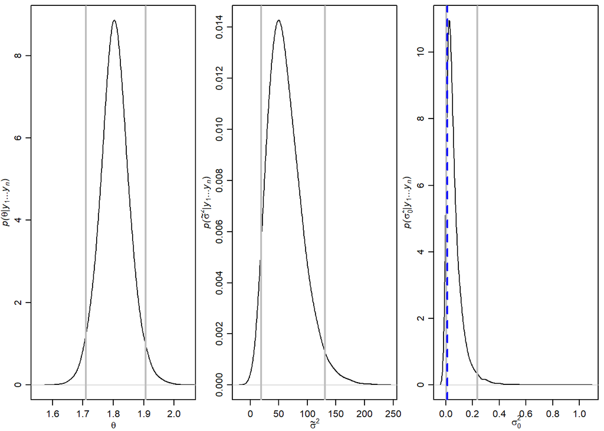

```r
par(mfrow=c(1,3),mar=c(2.75,2.75,.5,.5),mgp=c(1.70,.70,0))
sseq<-1:1000


plot(density(PHI3[,1],adj=2),  xlab=expression(theta),main="",
     xlim=c(1.55,2.05),
 ylab=expression( paste(italic("p("),
     theta,"|",italic(y[1]),"...",italic(y[n]),")",sep="")))
abline(v=quantile(PHI3[,1],prob=c(.025,.975)),lwd=2,col="gray")

plot(density(PHI3[,2],adj=2), xlab=expression(tilde(sigma)^2),main="",
     ylab=expression( paste(italic("p("),
     tilde(sigma)^2,"|",italic(y[1]),"...",italic(y[n]),")",sep="")))
abline(v=quantile(PHI3[,2],prob=c(.025,.975)),lwd=2,col="gray")

plot(density(PHI3[,3],adj=2), xlab=expression(sigma[0]^2),main="",
     ylab=expression( paste(italic("p("),
    sigma[0]^2,"|",italic(y[1]),"...",italic(y[n]),")",sep="")))
abline(v=quantile(PHI3[,3],prob=c(.025,.975)),lwd=2,col="gray")
abline(v=0.01,lwd=2,col="blue",lty=2)
```

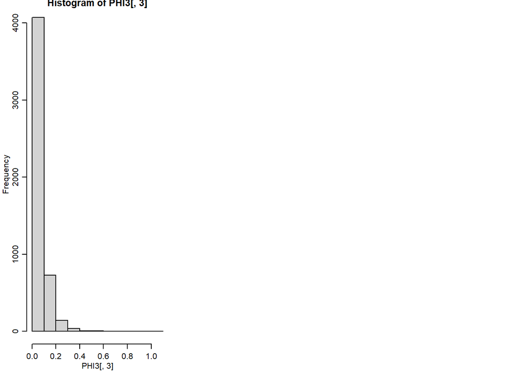

```r
hist(PHI3[,3])
```

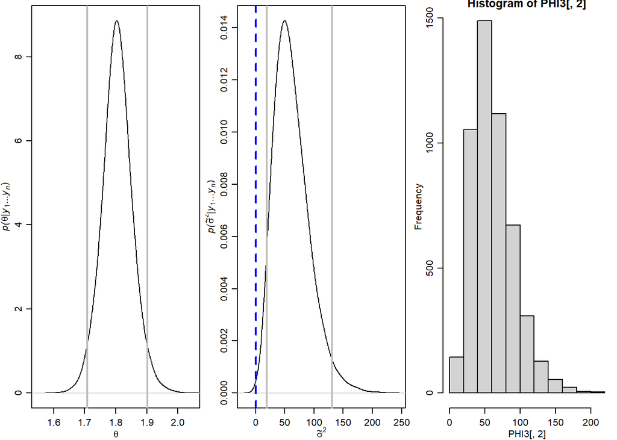

```r
## posterior marginal density
par(mfrow=c(1,3),mar=c(2.75,2.75,.5,.5),mgp=c(1.70,.70,0))
sseq<-1:1000




plot(density(PHI3[,1],adj=2),  xlab=expression(theta),main="",
     xlim=c(1.55,2.05),
 ylab=expression( paste(italic("p("),
     theta,"|",italic(y[1]),"...",italic(y[n]),")",sep="")))
abline(v=quantile(PHI2[,1],prob=c(.025,.975)),lwd=2,col="gray")

plot(density(PHI3[,2],adj=2), xlab=expression(tilde(sigma)^2),main="",
     ylab=expression( paste(italic("p("),
     tilde(sigma)^2,"|",italic(y[1]),"...",italic(y[n]),")",sep="")))
abline(v=quantile(PHI3[,2],prob=c(.025,.975)),lwd=2,col="gray")

abline(v=0.01,lwd=2,col="blue",lty=2)

hist(PHI3[,2])
```

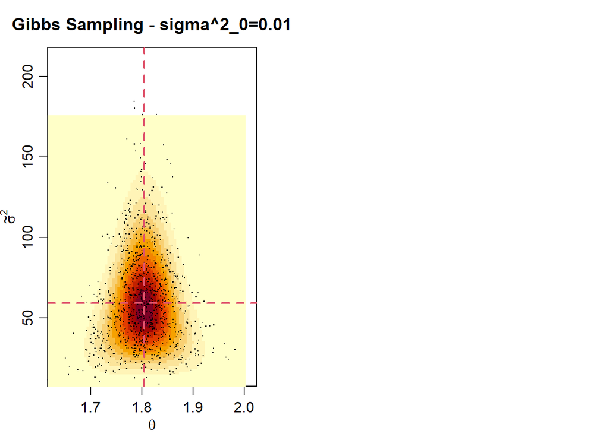

```r
## joint marginal
par(mfrow=c(1,2),mar=c(2.75,2.75,2.75,2.75),mgp=c(1.70,.70,0))
sseq<-1:1000

image( mean.grid,prec.grid,post.grid,
     xlab=expression(theta), ylab=expression(tilde(sigma)^2) ,
     xlim=range(PHI3[,1]),ylim=range(PHI3[,2]), main="Gibbs Sampling - sigma^2_0=0.01")
points(PHI3[sseq,1],PHI3[sseq,2],pch=".",cex=1.25 )
abline(v=MLE_1,lwd=2,lty=2,col=2)
abline(h=MLE_3,lwd=2,lty=2,col=2)
```

#### Case2 with a2 = 114514

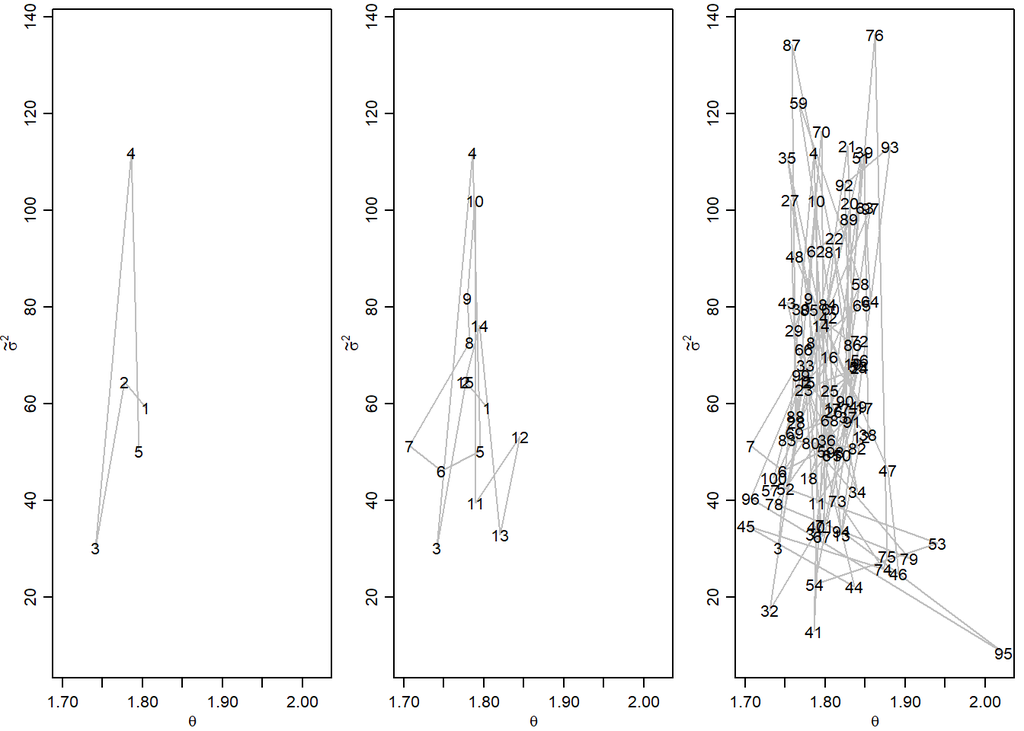

```r
a = 1
a2 = 114514
b = 100
set.seed(1)
S<-5000 # Number of samples
a<-1
b<-100

PHI<-matrix(nrow=S,ncol=3) # New change ncol=2 by ncol=3
PHI[1,]<-phi<-c( mean.y, 1/var.y, 0.01) # New: Include a new starting point

## Gibbs sampling algorithm

for(s in 2:S) {



# generate a new theta value from its full conditional

mun<-  ( mu0/t20 + n*mean.y*phi[2] ) / ( 1/t20 + n*phi[2] )
t2n<- 1/( 1/t20 + n*phi[2] )
phi[1]<-rnorm(1, mun, sqrt(t2n) )

# generate a new sigma^2 value from its full conditional
nun<- nu0+n
s2n<- (nu0*s20 + (n-1)*var.y + n*(mean.y-phi[1])^2 ) /nun
phi[2]<- rgamma(1, nun/2, nun*s2n/2)
beta <- rgamma(1, a, b)
phi[3] <-  rgamma(1, shape=a2 + nu0/2, rate= beta + (nu0/2)*phi[2])

PHI[s,]<-phi

                }

par(mfrow=c(1,3),mar=c(2.75,2.75,.5,.5),mgp=c(1.70,.70,0))
m1<-5
plot( PHI[1:m1,],type="l",xlim=range(PHI[1:100,1]), ylim=range(PHI[1:100,2]),
       lty=1,col="gray",xlab=expression(theta),ylab=expression(tilde(sigma)^2))
text(  PHI[1:m1,1], PHI[1:m1,2], c(1:m1) )

m1<-15
plot( PHI[1:m1,],type="l",xlim=range(PHI[1:100,1]), ylim=range(PHI[1:100,2]),
       lty=1,col="gray",xlab=expression(theta),ylab=expression(tilde(sigma)^2))
text(  PHI[1:m1,1], PHI[1:m1,2], c(1:m1) )

m1<-100
plot( PHI[1:m1,],type="l",xlim=range(PHI[1:100,1]), ylim=range(PHI[1:100,2]),
       lty=1,col="gray",xlab=expression(theta),ylab=expression(tilde(sigma)^2))
text(  PHI[1:m1,1], PHI[1:m1,2], c(1:m1) )
```

```r
PHI4<-PHI
```

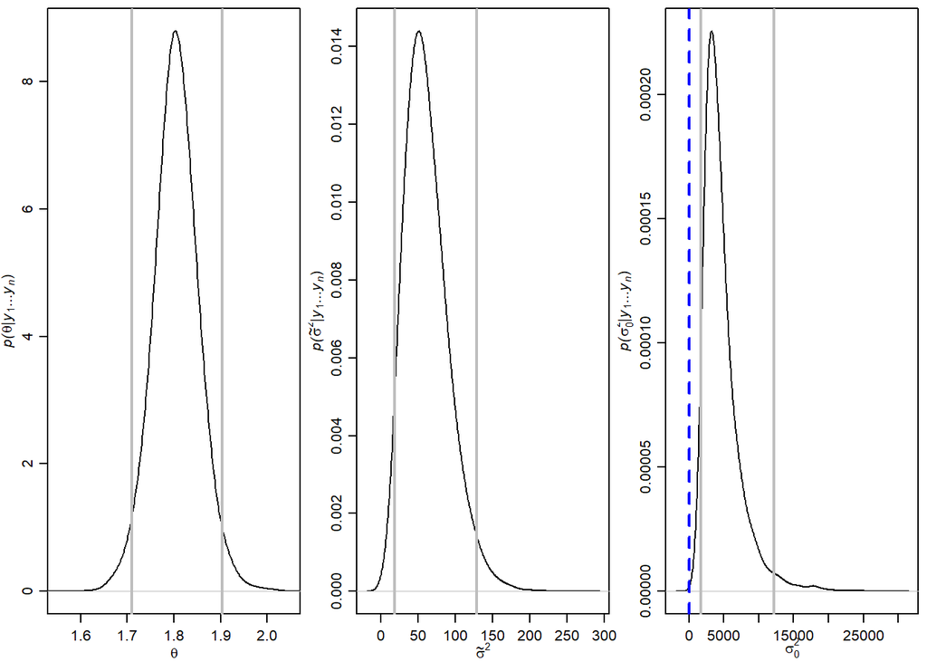

```r
par(mfrow=c(1,3),mar=c(2.75,2.75,.5,.5),mgp=c(1.70,.70,0))
sseq<-1:1000



plot(density(PHI4[,1],adj=2),  xlab=expression(theta),main="",
     xlim=c(1.55,2.05),
 ylab=expression( paste(italic("p("),
     theta,"|",italic(y[1]),"...",italic(y[n]),")",sep="")))
abline(v=quantile(PHI4[,1],prob=c(.025,.975)),lwd=2,col="gray")

plot(density(PHI4[,2],adj=2), xlab=expression(tilde(sigma)^2),main="",
     ylab=expression( paste(italic("p("),
     tilde(sigma)^2,"|",italic(y[1]),"...",italic(y[n]),")",sep="")))
abline(v=quantile(PHI4[,2],prob=c(.025,.975)),lwd=2,col="gray")

plot(density(PHI4[,3],adj=2), xlab=expression(sigma[0]^2),main="",
     ylab=expression( paste(italic("p("),
    sigma[0]^2,"|",italic(y[1]),"...",italic(y[n]),")",sep="")))
abline(v=quantile(PHI4[,3],prob=c(.025,.975)),lwd=2,col="gray")
abline(v=0.01,lwd=2,col="blue",lty=2)
```

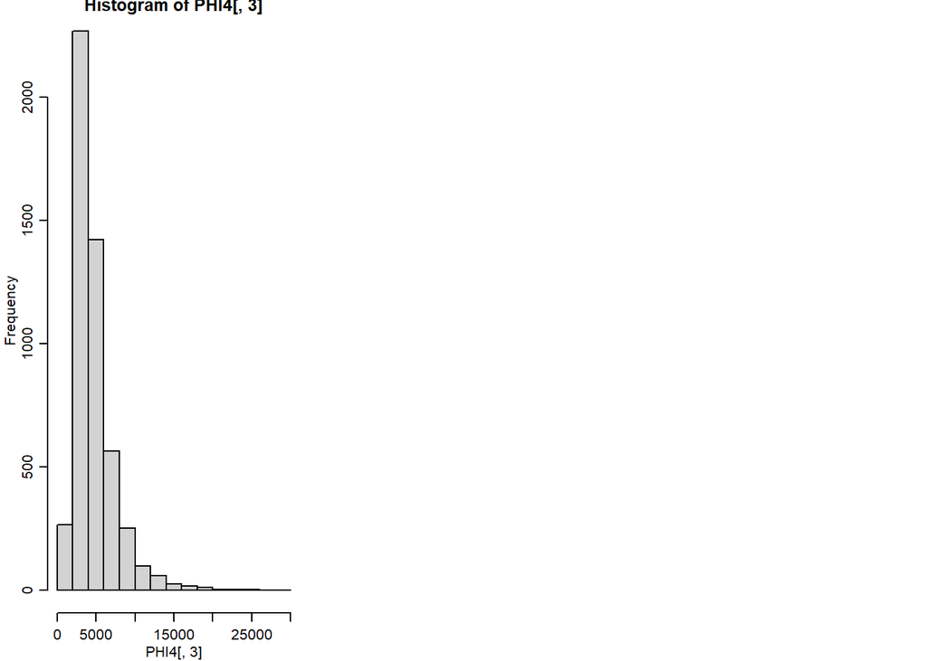

```r
hist(PHI4[,3])
```

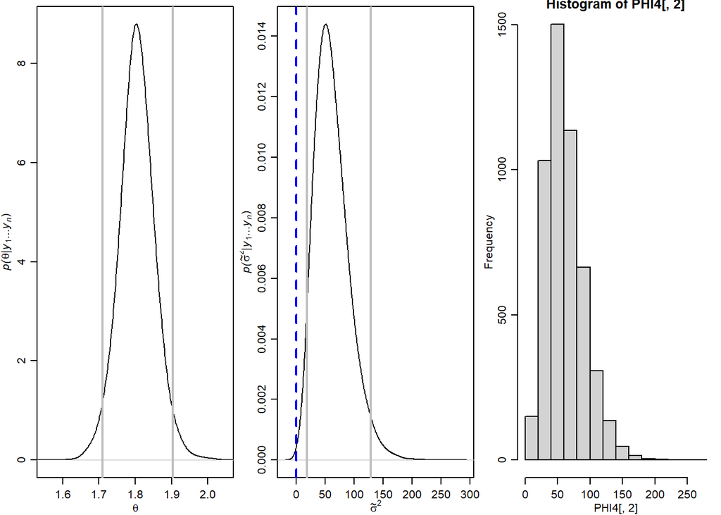

```r
par(mfrow=c(1,3),mar=c(2.75,2.75,.5,.5),mgp=c(1.70,.70,0))
sseq<-1:1000




plot(density(PHI4[,1],adj=2),  xlab=expression(theta),main="",
     xlim=c(1.55,2.05),
 ylab=expression( paste(italic("p("),
     theta,"|",italic(y[1]),"...",italic(y[n]),")",sep="")))
abline(v=quantile(PHI4[,1],prob=c(.025,.975)),lwd=2,col="gray")

plot(density(PHI4[,2],adj=2), xlab=expression(tilde(sigma)^2),main="",
     ylab=expression( paste(italic("p("),
     tilde(sigma)^2,"|",italic(y[1]),"...",italic(y[n]),")",sep="")))
abline(v=quantile(PHI4[,2],prob=c(.025,.975)),lwd=2,col="gray")

abline(v=0.01,lwd=2,col="blue",lty=2)

hist(PHI4[,2])
```

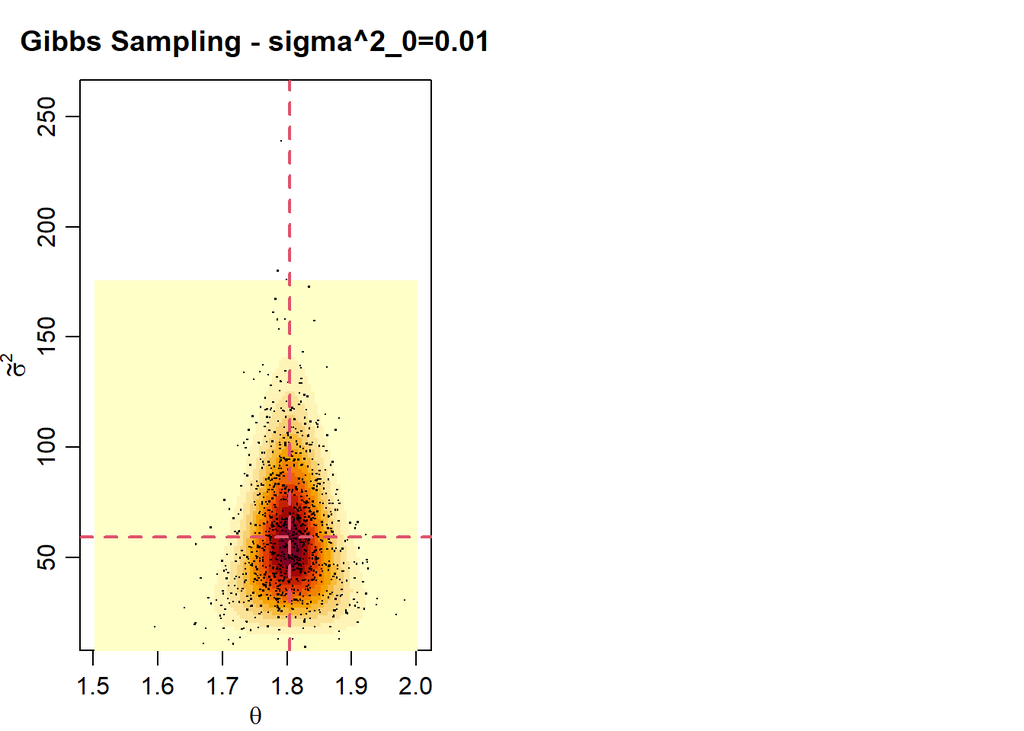

```r
## joint marginal
par(mfrow=c(1,2),mar=c(2.75,2.75,2.75,2.75),mgp=c(1.70,.70,0))
sseq<-1:1000

image( mean.grid,prec.grid,post.grid,
     xlab=expression(theta), ylab=expression(tilde(sigma)^2) ,
     xlim=range(PHI4[,1]),ylim=range(PHI4[,2]), main="Gibbs Sampling - sigma^2_0=0.01")
points(PHI4[sseq,1],PHI4[sseq,2],pch=".",cex=1.25 )
abline(v=MLE_1,lwd=2,lty=2,col=2)
abline(h=MLE_3,lwd=2,lty=2,col=2)
```

#### Case2 with a3 = 1145141919810

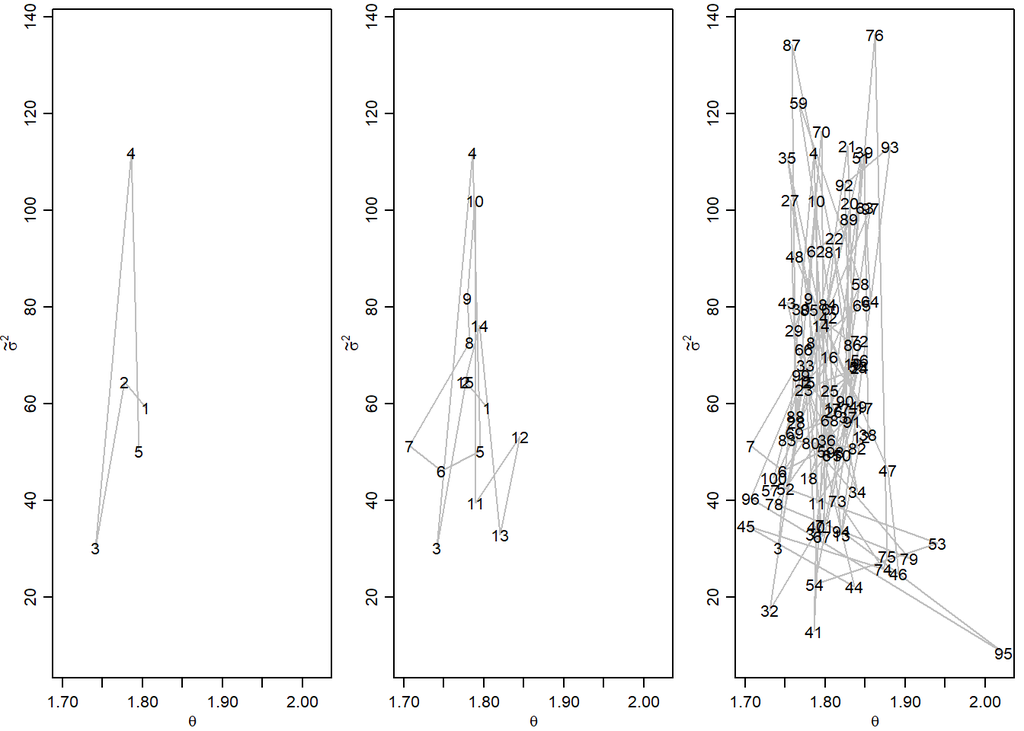

```r
a3 = 1145141919810
set.seed(1)
S<-5000 # Number of samples
a<-1
b<-100

PHI<-matrix(nrow=S,ncol=3) # New change ncol=2 by ncol=3
PHI[1,]<-phi<-c( mean.y, 1/var.y, 0.01) # New: Include a new starting point

## Gibbs sampling algorithm

for(s in 2:S) {



# generate a new theta value from its full conditional

mun<-  ( mu0/t20 + n*mean.y*phi[2] ) / ( 1/t20 + n*phi[2] )
t2n<- 1/( 1/t20 + n*phi[2] )
phi[1]<-rnorm(1, mun, sqrt(t2n) )

# generate a new sigma^2 value from its full conditional
nun<- nu0+n
s2n<- (nu0*s20 + (n-1)*var.y + n*(mean.y-phi[1])^2 ) /nun
phi[2]<- rgamma(1, nun/2, nun*s2n/2)
beta <- rgamma(1, a, b)
phi[3] <-  rgamma(1, shape=a3 + nu0/2, rate= beta + (nu0/2)*phi[2])

PHI[s,]<-phi

                }

par(mfrow=c(1,3),mar=c(2.75,2.75,.5,.5),mgp=c(1.70,.70,0))
m1<-5
plot( PHI[1:m1,],type="l",xlim=range(PHI[1:100,1]), ylim=range(PHI[1:100,2]),
       lty=1,col="gray",xlab=expression(theta),ylab=expression(tilde(sigma)^2))
text(  PHI[1:m1,1], PHI[1:m1,2], c(1:m1) )

m1<-15
plot( PHI[1:m1,],type="l",xlim=range(PHI[1:100,1]), ylim=range(PHI[1:100,2]),
       lty=1,col="gray",xlab=expression(theta),ylab=expression(tilde(sigma)^2))
text(  PHI[1:m1,1], PHI[1:m1,2], c(1:m1) )

m1<-100
plot( PHI[1:m1,],type="l",xlim=range(PHI[1:100,1]), ylim=range(PHI[1:100,2]),
       lty=1,col="gray",xlab=expression(theta),ylab=expression(tilde(sigma)^2))
text(  PHI[1:m1,1], PHI[1:m1,2], c(1:m1) )
```

```r
PHI5<-PHI
```

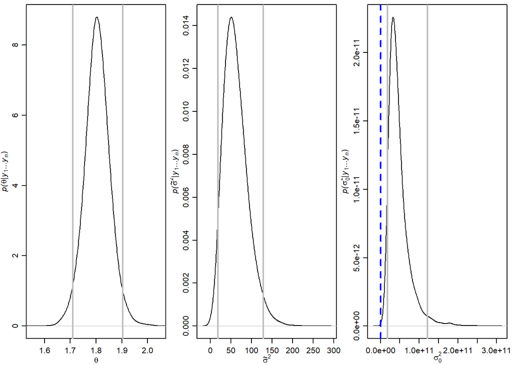

```r
par(mfrow=c(1,3),mar=c(2.75,2.75,.5,.5),mgp=c(1.70,.70,0))
sseq<-1:1000



plot(density(PHI5[,1],adj=2),  xlab=expression(theta),main="",
     xlim=c(1.55,2.05),
 ylab=expression( paste(italic("p("),
     theta,"|",italic(y[1]),"...",italic(y[n]),")",sep="")))
abline(v=quantile(PHI5[,1],prob=c(.025,.975)),lwd=2,col="gray")

plot(density(PHI5[,2],adj=2), xlab=expression(tilde(sigma)^2),main="",
     ylab=expression( paste(italic("p("),
     tilde(sigma)^2,"|",italic(y[1]),"...",italic(y[n]),")",sep="")))
abline(v=quantile(PHI5[,2],prob=c(.025,.975)),lwd=2,col="gray")

plot(density(PHI5[,3],adj=2), xlab=expression(sigma[0]^2),main="",
     ylab=expression( paste(italic("p("),
    sigma[0]^2,"|",italic(y[1]),"...",italic(y[n]),")",sep="")))
abline(v=quantile(PHI5[,3],prob=c(.025,.975)),lwd=2,col="gray")
abline(v=0.01,lwd=2,col="blue",lty=2)
```

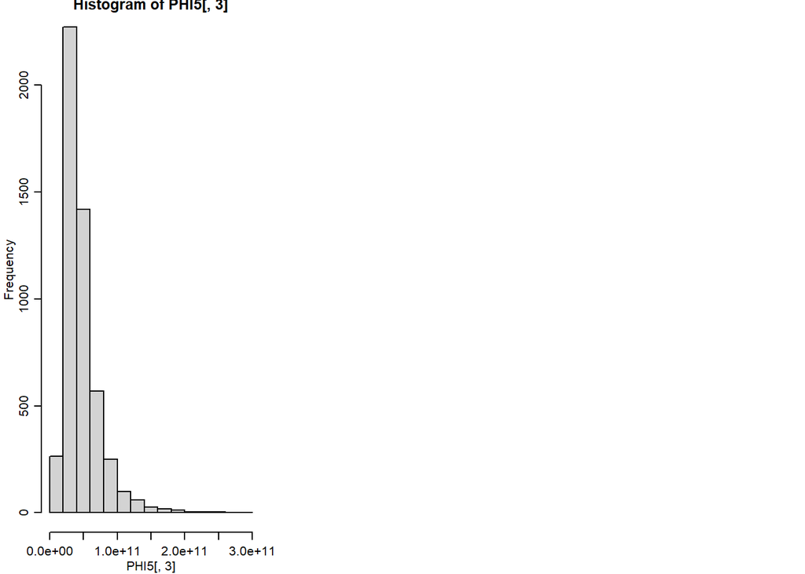

```r
hist(PHI5[,3])
```

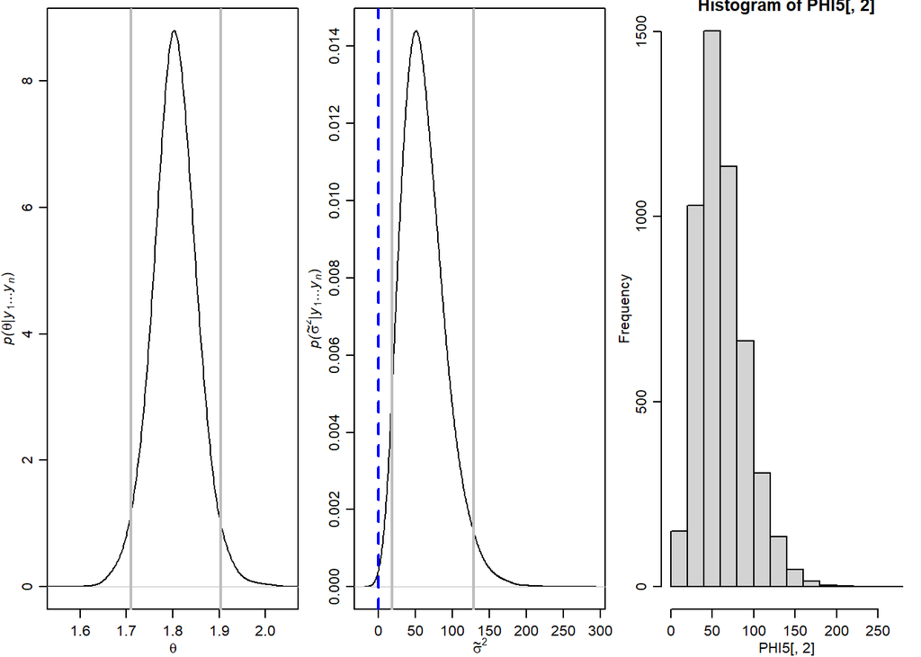

```r
par(mfrow=c(1,3),mar=c(2.75,2.75,.5,.5),mgp=c(1.70,.70,0))
sseq<-1:1000




plot(density(PHI5[,1],adj=2),  xlab=expression(theta),main="",
     xlim=c(1.55,2.05),
 ylab=expression( paste(italic("p("),
     theta,"|",italic(y[1]),"...",italic(y[n]),")",sep="")))
abline(v=quantile(PHI5[,1],prob=c(.025,.975)),lwd=2,col="gray")

plot(density(PHI5[,2],adj=2), xlab=expression(tilde(sigma)^2),main="",
     ylab=expression( paste(italic("p("),
     tilde(sigma)^2,"|",italic(y[1]),"...",italic(y[n]),")",sep="")))
abline(v=quantile(PHI5[,2],prob=c(.025,.975)),lwd=2,col="gray")

abline(v=0.01,lwd=2,col="blue",lty=2)

hist(PHI5[,2])
```

```r
quantile(PHI3[,1],prob=c(.025,.975))
```

```
##     2.5%    97.5%
## 1.710118 1.905782
```

```r
quantile(PHI3[,2],prob=c(.025,.975))
```

```
##     2.5%    97.5%
##  19.0681 131.0474
```

```r
summary(PHI3)
```

```
##        V1              V2                V3
##  Min.   :1.616   Min.   :  7.742   Min.   :0.0000687
##  1st Qu.:1.775   1st Qu.: 40.724   1st Qu.:0.0203084
##  Median :1.804   Median : 57.487   Median :0.0423530
##  Mean   :1.805   Mean   : 62.133   Mean   :0.0620326
##  3rd Qu.:1.834   3rd Qu.: 78.881   3rd Qu.:0.0818513
##  Max.   :2.024   Max.   :217.817   Max.   :1.0505429
```

```r
apply(PHI3,2,sd)
```

```
## [1]  0.04778416 29.31223894  0.06523668
```

```r
quantile(PHI4[,1],prob=c(.025,.975))
```

```
##     2.5%    97.5%
## 1.709172 1.903743
```

```r
quantile(PHI4[,2],prob=c(.025,.975))
```

```
##      2.5%     97.5%
##  18.80635 129.03207
```

```r
summary(PHI4)
```

```
##        V1              V2                V3
##  Min.   :1.480   Min.   :  7.782   Min.   :    0.01
##  1st Qu.:1.775   1st Qu.: 41.015   1st Qu.: 2915.95
##  Median :1.804   Median : 57.648   Median : 3965.60
##  Mean   :1.805   Mean   : 62.012   Mean   : 4696.61
##  3rd Qu.:1.834   3rd Qu.: 78.552   3rd Qu.: 5579.18
##  Max.   :2.023   Max.   :266.631   Max.   :29509.88
```

```r
apply(PHI4,2,sd)
```

```
## [1] 4.804995e-02 2.892493e+01 2.759225e+03
```

```r
quantile(PHI5[,1],prob=c(.025,.975))
```

```
##     2.5%    97.5%
## 1.709172 1.903743
```

```r
quantile(PHI5[,2],prob=c(.025,.975))
```

```
##      2.5%     97.5%
##  18.80635 129.03207
```

```r
summary(PHI5)
```

```
##        V1              V2                V3
##  Min.   :1.480   Min.   :  7.782   Min.   :0.000e+00
##  1st Qu.:1.775   1st Qu.: 41.036   1st Qu.:2.914e+10
##  Median :1.804   Median : 57.654   Median :3.970e+10
##  Mean   :1.805   Mean   : 62.023   Mean   :4.695e+10
##  3rd Qu.:1.834   3rd Qu.: 78.564   3rd Qu.:5.578e+10
##  Max.   :2.023   Max.   :266.631   Max.   :2.942e+11
```

```r
apply(PHI5,2,sd)
```

```
## [1] 4.805106e-02 2.892047e+01 2.758379e+10
```

#### Describe the effects of the prior choice for σ20 and β in your results. Consider posterior quantities such as credible intervals, variances, means and include posterior marginal and joint densities. (40 points)

In this case the σ20 is the none informative prior of the distribution , so we compares some of the extreme case of the distribution for σ20, although it has great effect on the sigma0^~ has a little influence on the credible intervals, variances, means and include posterior marginal and joint densities

we observed that as the a1 we selected greatly increase, the confidence interval converage alittle bit , but as sigma0^~ become more disperse, the converaing effect decreased.

Appendix:

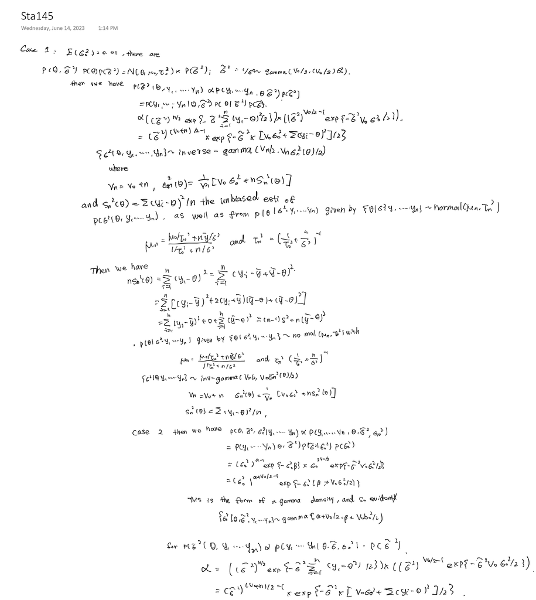

MCMC for case two:

```r
set.seed(1)
S<-5000

s2.postsample<-1/rgamma(S,  (nu0+n)/2, s2n*(nu0+n)/2 )

theta.postsample<-rnorm(S, mun, sqrt(s2.postsample/(k0+n)))


quantile(theta.postsample, c(.025,.975))
```

```
##    2.5%   97.5%
## 1.71785 1.88615
```

```r
##
layout(matrix(c(1,1,2,3),2,2,byrow=T))
par(mar=c(3,3,1,1),mgp=c(1.75,.75,0))
image(theta,s2g,exp(ld.th.s2),xlab=expression(theta),
       ylab=expression(sigma^2),xlim=c(1.60,2.0),ylim=c(.001,.07) )
points(theta.postsample[1:5000], s2.postsample[1:5000],pch=".",
   xlab=expression(theta),ylab=expression(sigma^2),xlim=c(1.65,1.95),
   ylim=c(.005,.07) )
plot(density(s2.postsample,adjust=3),main="",xlab=expression(sigma^2),
     xlim=c(0,.075),ylab=expression( paste(italic("p("),
     sigma^2,"|",italic(y[1]),"...",italic(y[n]),")",sep="")))
plot(density(theta.postsample,adjust=3),main="",xlab=expression(theta),
     xlim=c(1.60,2.0),ylab=expression( paste(italic("p("),
     theta,"|",italic(y[1]),"...",italic(y[n]),")",sep="")))
quantile( theta.postsample,c(.025,.975))
```

```
##    2.5%   97.5%
## 1.71785 1.88615
```

```r
abline(v=quantile( theta.postsample,c(.025,.975)),col="gray",lwd=2)

## t-test based confidence interval
n<-length(y) ; ybar<-mean(y) ; s2<-var(y)

ybar+qt( c(.025,.975), n-1) *sqrt(s2/n)
```

```
## [1] 1.704583 1.904306
```

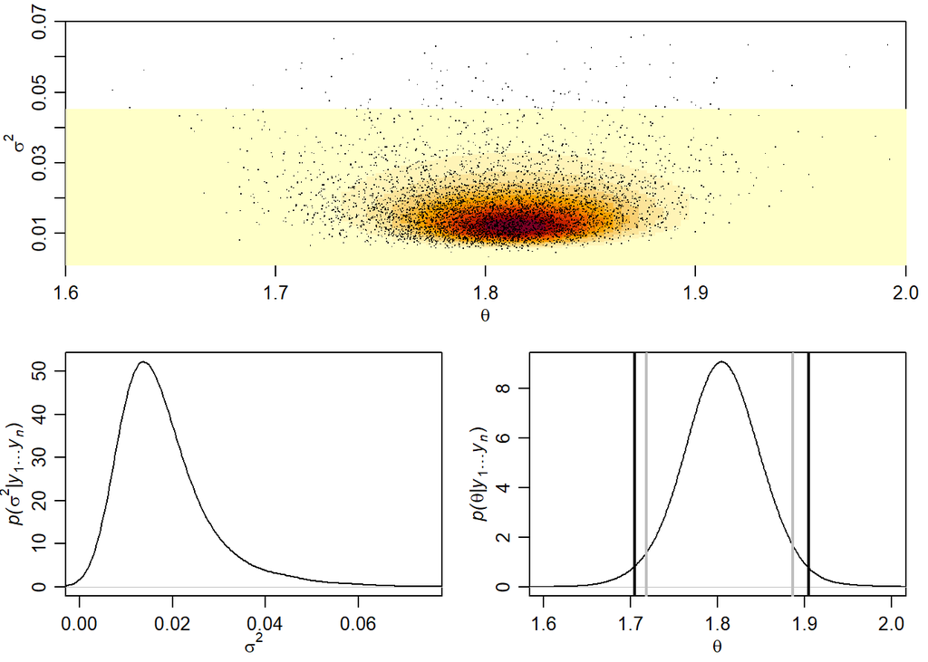

```r
abline( v= ybar+qt( c(.025,.975), n-1) *sqrt(s2/n), col="black",lwd=2)
```

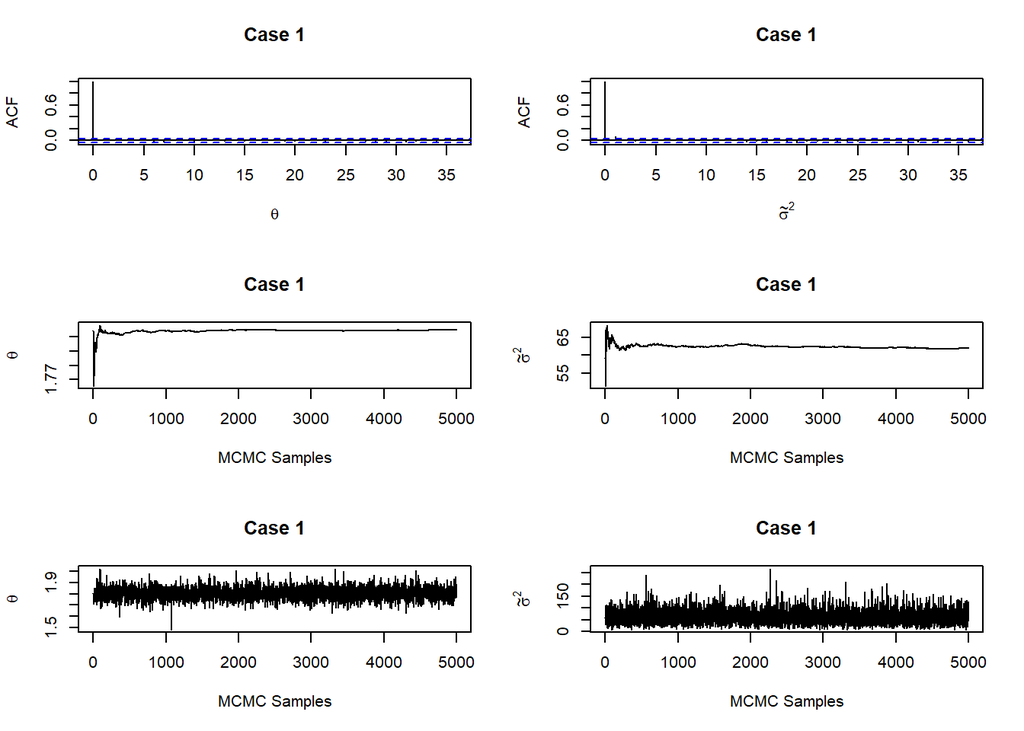

```r
par(mfrow=c(3,2))

# Autocorrelation function

acf(PHI4[,1],main="Case 1", xlab=expression(theta))
acf(PHI4[,2],main="Case 1", xlab=expression(tilde(sigma)^2))

# Ergodic mean

plot(ergMean(PHI4[,1]),main="Case 1", ylab=expression(theta),xlab="MCMC Samples",type="l")
plot(ergMean(PHI4[,2]),main="Case 1", ylab=expression(tilde(sigma)^2),xlab="MCMC Samples",type="l")

# Mixing

plot(PHI4[,1],main="Case 1", ylab=expression(theta),xlab="MCMC Samples",type="l")
plot(PHI4[,2],main="Case 1", ylab=expression(tilde(sigma)^2),xlab="MCMC Samples",type="l")
```

There should not be difference for MCMC between the case two, that is because the weak infomative prior has little to null contribution to the overall distribution and would not influence the answer by Monte Carlo method